# TP 2021

**But du TP** : L’objectif de ce projet est d’évaluer les compétences de chaque étudiant à écrire des codes de simulation de variables aléatoires quelconque et leur intégration dans des modèles divers pour analyse. Il a été vu plusieurs méthodes de simulation de variables aléatoires parmi lesquelles le changement de variable et la méthode d’inverse de la fonction de répartition. On fait l’étude sur la modélisation de la croissance en diamètre (en $cm$) d’un arbre au sein d’une forêt. $X_k$ (k correspond à une année) est le diamètre (en $cm$) à l’instant k, la suite $X_0; X_1; · · · ; X_k$ (encore notée ($X_k$)$k≥0$) est un processus (de Markov) qui modélise l’évolution annuelle du diamètre d’un arbre ou l’état initial $X_0$ suit une loi normale $X_0 ∼ \mathcal{N} (10.; 1.^2)$ car les arbres sont généralement inventoriés à partir de 10 $cm$. Le diamètre à l’instant $k$ dépend de celui à l’instant $k − 1$, ainsi, la loi de transition de $X_{k−1}$ vers $X_k$,$k ≥ 1$ est inspirée d’un modèle de croissance celui de *Gompertz* [Gom25] et peut s’écrire comme suit :
$$X_k = D^{1-exp^{-r}}X_{k-1}^{exp^{-r}}\epsilon_{k-1}$$
pour $k≥1$

suite des infos tu TP:
$$f(x) = \begin{cases} sin(x) & si & 0<x<\frac{\pi}{2}\\ 0 & sinon\end{cases}$$

# Partie 1 : Ecriture du simulateur de la loi du bruit $\epsilon_k$

Au préalable, il est nécessaire de calculer $F$ et $F^{-1}$ afin d’écrire le simulateur du bruit. Après calculs usuels sur la fonction de répartition, on obtient: Par définition, nous avons :

$F(x) = \mathcal{P}(X≤x) =\int_{-\infty}^{x} f(x)dx = \int_{0}^{+\infty} f(x)dx$, ce qui donne :

- Si $x<0$, alors $F(x) = 0$
- Si $0≤x<\frac{\pi}{2}$, alors $F(x) =\int_{0}^{x} f(t)dt = \int_{0}^{x} cos(t)dt =[-cos(t)]^{x}_{0} = 1- cos(x)$
- Si $x > \frac{\pi}{2}$, alors $F(x) = 1$

D’ou:
$$F(x) = \begin{cases} 0 & si & x<0 \\ 1-cos(x) & si & 0≤x<\frac{\pi}{2} \\ 1 & si & x > \frac{\pi}{2} \end{cases}$$

Pour son inverse, faisons ceci :

posons $y = F(x) = 1-cos(x)$, donc $cos(x) = 1-y$, en conjugant des deux côtés par $arcos$, on obtient : $y = arcos(1-x)$

D’ou

$$F^{-1}(x) = \begin{cases} arcos(1-x) & si & & 0≤x<1\\ 0 & sinon \end{cases}$$

```r
#  fonction de répartition de d'epsilon le bruit
Fforet = function(x){
  if(x<0){
    return(0)
  }
  else{
    if((x>=0)&&(x<pi/2)){
      return (1-cos(x))
    }else{
      return(1)
    }
  }
}


# Fonction inverse de la fonction de répartition
invForest = function(x){
  if((x>=0)&&(x<=1)){
    return(acos(1-x))
  }else{
    return(0)
  }
}

# fonction pour avoir la quantile d'ordre q
qForest = function(p){
  # car q = F^-1(p) et p = F(q)
  return(invForest(p))
}

# fonction pour avoir la probabilité
pForest = function(q){
  return(Fforet(q))
}

# fonction densité
dForest = function(x, log=FALSE){
  if((x>0)&&(x<pi/2)){
    if(log==TRUE){
      return(log(sin(x)))
    }else{
      return(sin(x))
    }
  }else{
    return(0)
  }
}

# fonction pour générer les nombres aléatoires tirés de cette loi
rForest = function(n){
  return(invForest(runif(n)))
}
```

Afin d’effectuer des comparaisons, traçons les fonction de densité et de répartition :

1. Traçé de la fonction de densité

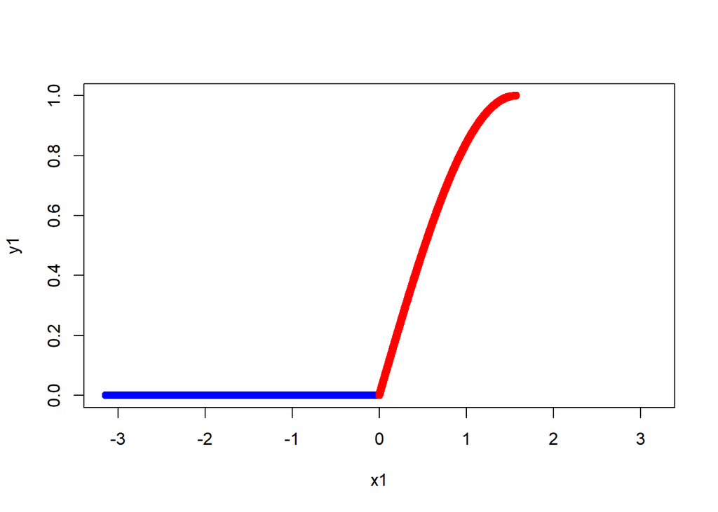

```r
# Partie 2 : Test des fonction et représentation des histogrammes
#
# on génère des nombres entre -pi et pi afin de représenter la première partie de f(x)
x1 = seq(from=-pi, to=0, by = .001)
y1 = rep(0, length(x1))
plot(x1,y1, xlim = c(-pi,pi),ylim=c(0,1),col="blue")
# on génères des nombres entre 0 et pi/2 afin de représenter la seconde partie de f(x)
x2 = seq(from=0, to=pi/2, by=.001)
points(x2, sin(x2), type='b', col="red")
```

```r
# cette combinaison nous produit la fonction de densité de f
```

2. Traçé de la fonction de répartition

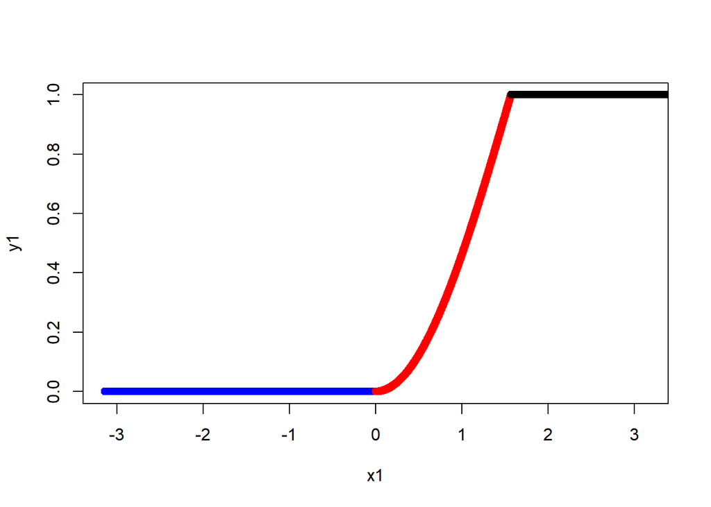

```r
# cette dernière sera découpée en 3 parties d'après nos calculs

x1 = seq(from=-pi, to=0, by = .001)
y1 = rep(0, length(x1))
plot(x1,y1, xlim = c(-pi,pi),ylim=c(0,1),col="blue")
# on génères des nombres entre 0 et pi/2 afin de représenter la seconde partie de f(x)
x2 = seq(from=0, to=pi/2, by=.001)
points(x2, (1-cos(x2)), type='b', col="red")

# enfin, on génère des nombres de pi/2 à 5 par exemple dont l'ordonée sera 1
x3 = seq(from=pi/2, to=5, by = .001)
y3 = rep(1, length(x3))
points(x3,y3)
```

3. Traçé de la fonction de densité codée par nous

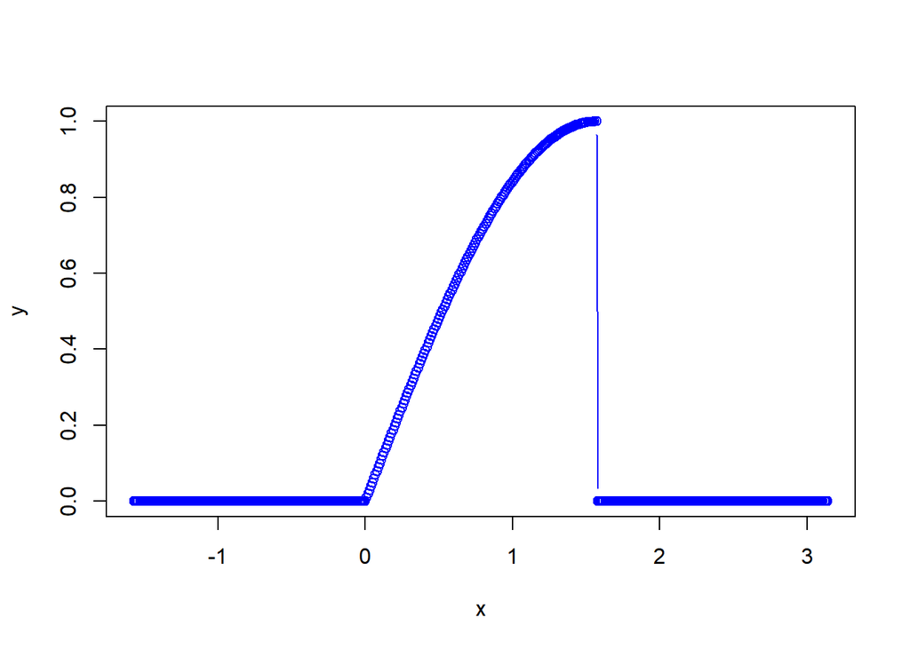

```r
# on génère des nombres dans [-pi/2; pi]

x = seq(from=-pi/2, to=pi, by=.01)
y = rep(0, length(x))
# pour chaque x, on applique la fonction dForest
for(i in 1:length(x))
  y[i] = dForest(x[i])

plot(x,y, col="blue", type = "b")
```

4. Traçé de la fonction de répartition codée par nous

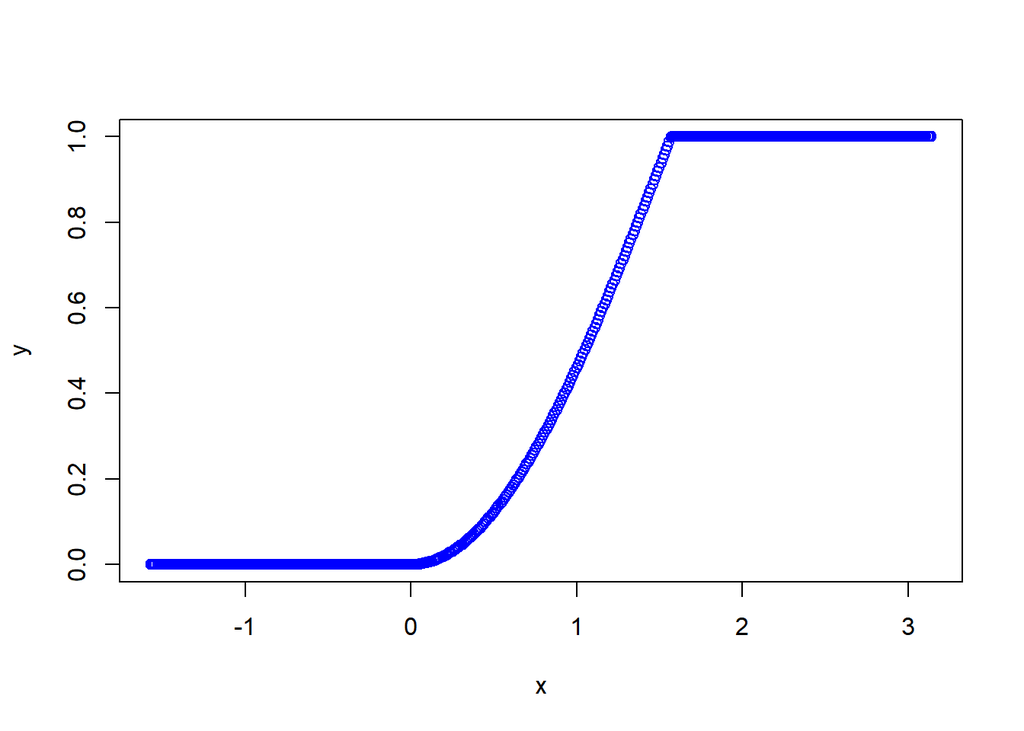

```r
# on génère des nombres dans [-pi/2; pi]

x = seq(from=-pi/2, to=pi, by=.01)
y = rep(0, length(x))
# pour chaque x, on applique la fonction dForest
for(i in 1:length(x))
  y[i] = Fforet(x[i])

plot(x,y, col="blue", type = "b")
```

**En resumé** : les graphes de nos fonction codées sont quasi similaires à ceux des fonction de densités et répartition issues de la définition et des calculs.

# Partie 3 : Utilisation du simulateur de bruit pour simuler les réalisation du modèle de croissance

Dans cette partie, nous allons simuler et tracer un certains nombres de valeurs obtenues à l’issue de cette simulation de notre modèle

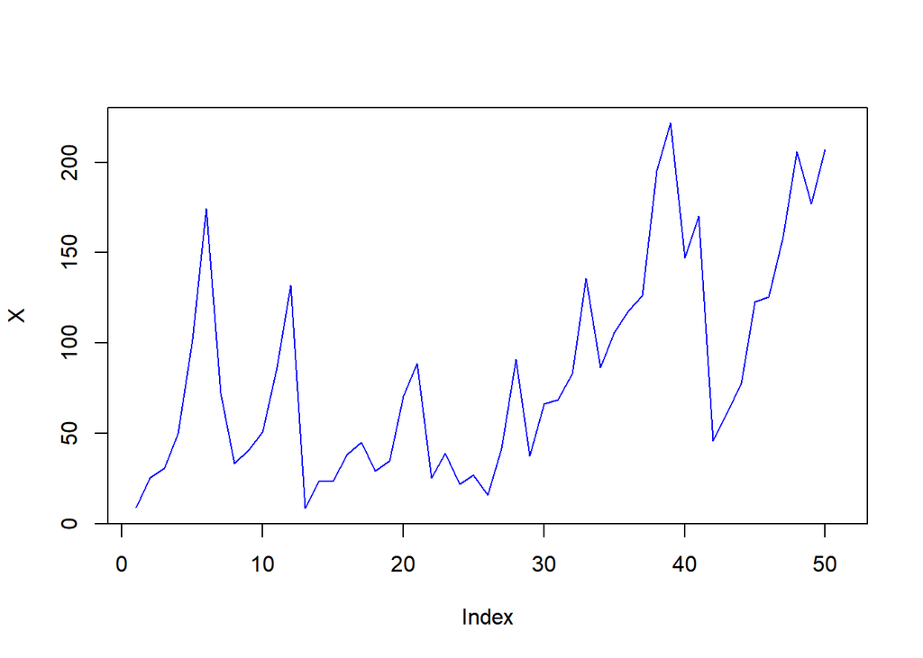

```r
D = 150
r=.3
X0 = rnorm(1.,10.)
X = rep(X0,51)
# initialisation du seed
set.seed(20)
eps_k = rForest(50)
for(i in 2:51){
  X[i] = (D^(1-exp(-r))* X[i-1]^(exp(-r)))*eps_k[i]
}
plot(X,type = 'l', col="blue")
```

Cette simulation laisse croire que le diamètre de l’arbre a tendance a croitre, puis se retrécir. Ce qui semble abérant par rapport à l’ordre naturel des choses. On peut donc conclure que le bruit choisit ne reflète pas fidèlement la réalité.

# Partie 4 : Année de plus grande taille de l’arbre et valeur

En utilisant les données simulées , on a :

| Année Max | Taille Max |
| --- | --- |
| 39 | 221.7207362 |

# Partie 5 : Simulation de 10 réalisation du modèle sur 50 années, avec graphiques

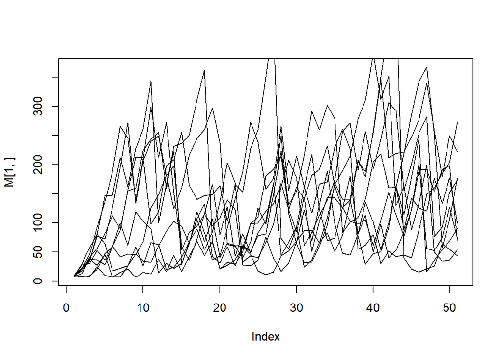

```r
kmax = 50
nbRealisations = 10
newTrajectory = function(){
  X0 = rnorm(1,10)
  X = rep(X0,kmax+1)
  e_k = rForest(kmax)
  for(i in 1:kmax){
    X[i+1] = (D^(1-exp(-r))* X[i]^(exp(-r)))*e_k[i]
  }
  return(X)
}

M = matrix(0, nrow = nbRealisations, ncol = kmax+1)
for(i in 1:nbRealisations){
  M[i,] = newTrajectory()
}

plot(M[1,], type = 'l')
for(i in 2:nbRealisations){
  points(M[i,], type = 'l')
}
```

# Partie 6 : Simulations similaires mais en utilisant un bruit logNormal

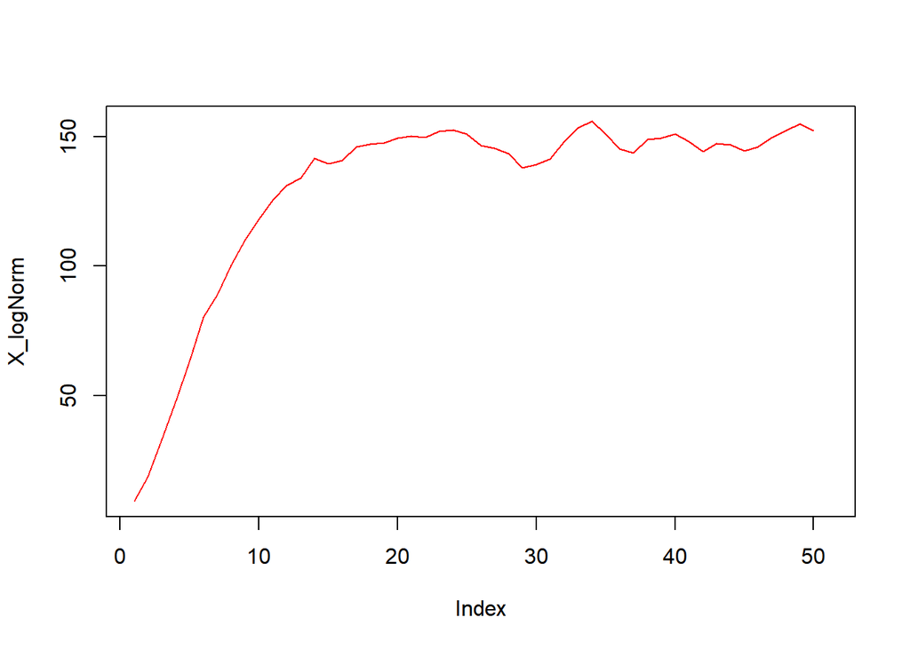

```r
# initialisation du seed
set.seed(20)
X_logNorm = rep(X0,51)
eps_k_lg = rlnorm(50,0,.02)
for(i in 2:51){
  X_logNorm[i] = (D^(1-exp(-r))* X_logNorm[i-1]^(exp(-r)))*eps_k_lg[i]
}
plot(X_logNorm,type = 'l', col="red")
```

En utilisant les données simulées , on a :

| Année Max | Taille Max |
| --- | --- |
| 34 | 155.9329672 |